# Logistic Regression For Binary Classification

## Introduction

For students who have studied cell biology and biochemistry, logistic regression may already be familiar. It may also be known as a *sigmoidal curve*, *dose-response curve*, *4-parameter fit*, a *median lethal dose curve* (LD-50) or even an exponential growth curve given limited resources. However to some biologists it is not generally thought of in terms of the decision boundary for binary classification.

In its simplest form we can use the formula given the Logistic / Sigmoidal Curve in the figure above.

$$f(x) = ~~ \left \{ \begin{matrix} 0 ~~for~~ x < 0.5 \\ 1 ~~for~~ x \geq 0.5 \end{matrix} \right.$$

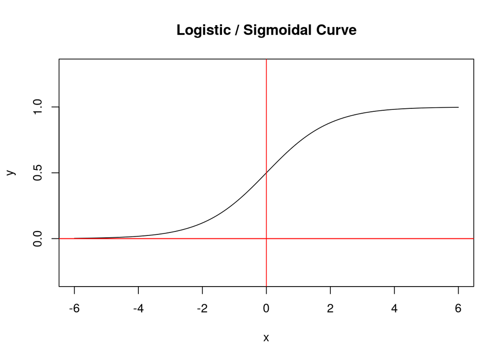

The logistic curve can be denoted by:

$$f(x) ~=~ \Large \frac{M}{1 + e^{-r(t - t_0)}}$$

where $M$ is maximum value, $r$ is the maximum growth rate (sometimes called the Malthusian parameter [^1]), $t_0$ is the midpoint of the curve.

In linear regression we assume that this mean may be expressed as an equation linear in x (or some transformation of x or Y) such as
$$E(Y | x) = \beta_0 + \beta_1 x_1 +~ ... ~+ \beta_{n} x_{n}$$
However with dichotomous data the conditional mean must be greater than of equal to zero and less than or equal to 1.

$$ln \left( \frac {p}{1-p} \right) =~ \beta_0 + \beta_1 x_1 +~ ... ~+ \beta_{n} x_{n}$$

```r
## Load Libraries
Libraries <- c("doMC", "knitr", "readr", "tidyverse", "caret")

for (p in Libraries) {  # Install Library if not present
    if (!require(p, character.only = TRUE)) { install.packages(p)
        }
    library(p, character.only = TRUE)
}
opts_chunk$set(cache = TRUE, warning = FALSE, message = FALSE)
```

```r
# Import data & data handling
c_m_TRANSFORMED <- read_csv("../00-data/02-aac_dpc_values/c_m_TRANSFORMED.csv",
                            col_types = cols(Class = col_factor(levels = c("0","1")),
                                             PID = col_skip(), TotalAA = col_skip()))
```

```r
# Partition data into training and testing sets
set.seed(1000)
index <- createDataPartition(c_m_TRANSFORMED$Class, p = 0.8, list = FALSE)

training_set.1 <- c_m_TRANSFORMED[index,]
#test_set.1     <- c_m_TRANSFORMED[-index,] # NOT needed since this run is not kept
#Class_test <- as.factor(test_set.1$Class) # NOT needed since this run is not kept
```

The `test.set.1` and `Class.test` data sets are not produced due to the fact that the Logit run with 20 features was not deamed useful. The reason for it dismissal was that is contained features which were extraneous.

## Logit Training #1 using 20 Features

```r
set.seed(1000)
registerDoMC(cores = 3)  # Start multi-processor mode
start_time <- Sys.time() # Start timer

# Create model, 10X fold CV repeated 5X
tcontrol <- trainControl(method = "repeatedcv",
                         number = 10,
                         repeats = 5)

model_obj.1 <- train(Class ~ .,
                     data = training_set.1,
                     trControl = tcontrol,
                     method = "glm",
                     family = "binomial")

end_time <- Sys.time()   # End timer
end_time - start_time    # Display time
```

```
## Time difference of 1.834468 secs
```

```r
registerDoSEQ() # Stop multi-processor mode
```

### `glm/binomial`: Quick Summary

```r
model_obj.1
```

```
## Generalized Linear Model
##
## 1873 samples
##   20 predictor
##    2 classes: '0', '1'
##
## No pre-processing
## Resampling: Cross-Validated (10 fold, repeated 5 times)
## Summary of sample sizes: 1685, 1686, 1686, 1686, 1686, 1685, ...
## Resampling results:
##
##   Accuracy   Kappa
##   0.9427734  0.8851613
```

## `glm/binomial`: Summary #1

```r
summary(model_obj.1)
```

```
##
## Call:
## NULL
##
## Deviance Residuals:
##     Min       1Q   Median       3Q      Max
## -5.9372  -0.2835  -0.0194   0.0516   3.6884
##
## Coefficients:
##             Estimate Std. Error z value Pr(>|z|)
## (Intercept)   8.0525     9.2156   0.874 0.382234
## A             5.0438     9.6899   0.521 0.602699
## C           -14.2228     2.6949  -5.278 1.31e-07 ***
## D           -36.2676     8.0845  -4.486 7.25e-06 ***
## E            27.6016    11.1292   2.480 0.013135 *
## F             5.6174     5.2654   1.067 0.286034
## G           -22.1970    10.3043  -2.154 0.031229 *
## H            90.1101    12.1105   7.441 1.00e-13 ***
## I            -5.9795     4.3945  -1.361 0.173610
## K            -2.8961     9.8468  -0.294 0.768669
## L            -3.7417     9.2217  -0.406 0.684926
## M            -0.1427    12.0747  -0.012 0.990570
## N             3.3478     9.6749   0.346 0.729319
## P           -39.7466    11.1010  -3.580 0.000343 ***
## Q            -5.6804    11.2516  -0.505 0.613664
## R           -83.6045    11.8104  -7.079 1.45e-12 ***
## S            -9.9745    10.0872  -0.989 0.322750
## T           -36.5980     9.2791  -3.944 8.01e-05 ***
## V            16.3411     9.7859   1.670 0.094946 .
## W             9.0169    13.8870   0.649 0.516141
## Y           -31.9282    11.1167  -2.872 0.004078 **
## ---
## Signif. codes:  0 '***' 0.001 '**' 0.01 '*' 0.05 '.' 0.1 ' ' 1
##
## (Dispersion parameter for binomial family taken to be 1)
##
##     Null deviance: 2593.68  on 1872  degrees of freedom
## Residual deviance:  657.72  on 1852  degrees of freedom
## AIC: 699.72
##
## Number of Fisher Scoring iterations: 8
```

## Logit Training #2 using 9 Features

- Using **ONLY** features: (C, D, G, H, P, R, S, T, Y)

Data import & handling

```r
c_m_9aa <- read_csv("../00-data/02-aac_dpc_values/c_m_TRANSFORMED.csv",
    col_types = cols(A = col_skip(), Class = col_factor(levels = c("0", "1")),
                     E = col_skip(), F = col_skip(),
                     I = col_skip(), K = col_skip(),
                     L = col_skip(), M = col_skip(),
                     N = col_skip(), PID = col_skip(),
                     Q = col_skip(), TotalAA = col_skip(),
                     V = col_skip(), W = col_skip()))
```

Partition data into training and testing sets

```r
set.seed(1000)
index <- createDataPartition(c_m_9aa$Class, p = 0.8, list = FALSE)

training_set.2 <- c_m_9aa[ index, ]
test_set.2     <- c_m_9aa[-index, ]

Class_test.2 <- as.factor(test_set.2$Class)
```

## `glm/binomial`: Training #2 Logit with 9 Features

```r
set.seed(1000)
registerDoMC(cores = 3)  # Start multi-core
start_time <- Sys.time() # Start timer

# Create model, 10X fold CV repeated 5X
fitControl <- trainControl(method = "repeatedcv",
                         number = 10,
                         repeats = 5,
                         savePredictions = "final") # IMPORTANT: Saves predictions

model_obj.2 <- train(Class ~ .,
                       data = training_set.2,
                       trControl = fitControl,
                       method = "glm",
                       family = "binomial")

end_time <- Sys.time()   # End timer
end_time - start_time    # Display time
```

```
## Time difference of 1.434278 secs
```

```r
registerDoSEQ()          # Stop multi-core
```

## `glm/binomial` Summary #2

```r
summary(model_obj.2)
```

```
##
## Call:
## NULL
##
## Deviance Residuals:
##     Min       1Q   Median       3Q      Max
## -4.9039  -0.3154  -0.0214   0.0731   3.5631
##
## Coefficients:
##             Estimate Std. Error z value Pr(>|z|)
## (Intercept)  12.0243     0.8996  13.366  < 2e-16 ***
## C           -14.2812     1.9856  -7.193 6.36e-13 ***
## D           -35.2157     4.8387  -7.278 3.39e-13 ***
## G           -30.0523     4.5101  -6.663 2.68e-11 ***
## H            85.5369     8.3261  10.273  < 2e-16 ***
## P           -35.7410     6.0074  -5.949 2.69e-09 ***
## R           -81.5443     6.1135 -13.338  < 2e-16 ***
## S           -14.0105     5.4851  -2.554   0.0106 *
## T           -48.7590     5.5909  -8.721  < 2e-16 ***
## Y           -34.7928     6.3133  -5.511 3.57e-08 ***
## ---
## Signif. codes:  0 '***' 0.001 '**' 0.01 '*' 0.05 '.' 0.1 ' ' 1
##
## (Dispersion parameter for binomial family taken to be 1)
##
##     Null deviance: 2593.68  on 1872  degrees of freedom
## Residual deviance:  701.04  on 1863  degrees of freedom
## AIC: 721.04
##
## Number of Fisher Scoring iterations: 7
```

## `glm/binomial`: Predict test_set.2

```r
Predicted_test_vals <- predict(model_obj.2, test_set.2[, -1])

summary(Predicted_test_vals)
```

```
##   0   1
## 247 220
```

## `glm/binomial`: Confusion Matrix #2

```r
confusionMatrix(Predicted_test_vals, Class_test.2, positive = "1")
```

```
## Confusion Matrix and Statistics
##
##           Reference
## Prediction   0   1
##          0 234  13
##          1   9 211
##
##                Accuracy : 0.9529
##                  95% CI : (0.9295, 0.9702)
##     No Information Rate : 0.5203
##     P-Value [Acc > NIR] : <2e-16
##
##                   Kappa : 0.9056
##
##  Mcnemar's Test P-Value : 0.5224
##
##             Sensitivity : 0.9420
##             Specificity : 0.9630
##          Pos Pred Value : 0.9591
##          Neg Pred Value : 0.9474
##              Prevalence : 0.4797
##          Detection Rate : 0.4518
##    Detection Prevalence : 0.4711
##       Balanced Accuracy : 0.9525
##
##        'Positive' Class : 1
##
```

## Obtain False Positives & False Negatives

```r
fp_fn_logit <- model_obj.2 %>% pluck("pred") %>% dplyr::filter(obs != pred)

# Write CSV in R
write.table(fp_fn_logit,
            file = "../20-outliers/fp_fn_logit.csv",
            row.names = FALSE,
            na = "",
            col.names = TRUE,
            sep = ",")

head(fp_fn_logit)
```

```
##   parameter pred obs rowIndex    Resample
## 1      none    1   0        2 Fold01.Rep1
## 2      none    1   0        8 Fold01.Rep1
## 3      none    1   0      547 Fold01.Rep1
## 4      none    0   1     1034 Fold01.Rep1
## 5      none    0   1     1041 Fold01.Rep1
## 6      none    0   1     1128 Fold01.Rep1
```

## Conclusion

model.1 Null deviance: 2593.68 on 1872 degrees of freedom Residual deviance: 657.72 on 1852 degrees of freedom AIC: 699.72

model.2 Null deviance: 2593.68 on 1872 degrees of freedom Residual deviance: 701.04 on 1863 degrees of freedom AIC: 721.04

Logit is good for parameter importance

[^1]: https://en.wikipedia.org/wiki/Malthusian_growth_model